# Immune Subtypes

Qirui Zhang, Siming Zhao

2026-10-29

# Pan-cancer differential selection across immune subtypes (Fig. 5a)

To characterize immune-associated differential selection at the pan-cancer level, we pooled tumor samples across cancer types (**8,253 tumors across 27 TCGA cancer types**) rather than analyzing each tumor type separately. Starting from the 299 driver genes of Bailey et al., each gene was tested for differential selection between each immune subtype and all remaining subtypes (Thorsson **C1–C4, one-vs-rest**), adjusting for patient age, sex, and tumor type (sex dropped for single-sex cohorts, tumor type for single-tumor cohorts). The Benjamini–Hochberg FDR was computed separately across all genes **within each immune subtype**.

Pipeline (see `code/`): `run_cohort_multi.R` / `recover_cohort.R` run the 299 gene-cohorts; `aggregate_pancancer299.R` combines the per-cohort C1–C4 results into `data/pancancer299_immune_aggregated.txt`.

```r
suppressMessages(library(data.table)); library(ggplot2); library(DT)
agg       <- fread("data/pancancer299_immune_aggregated.txt")
n_genes   <- length(unique(agg$gene))
sig       <- agg[dd.fdr < 0.1]
sig_genes <- sort(unique(sig$gene))
cat("Driver genes tested:", n_genes, "\n")
```

```
Driver genes tested: 220
```

```r
cat("Genes with FDR < 0.1 in >=1 immune subtype:", length(sig_genes),
    sprintf("(%.1f%%)\n", 100 * length(sig_genes) / n_genes))
```

```
Genes with FDR < 0.1 in >=1 immune subtype: 18 (8.2%)
```

```r
cat("Significant genes:", paste(sig_genes, collapse = ", "), "\n")
```

```
Significant genes: BRCA1, CASP8, CIC, COL5A1, EGFR, EZH2, FAT1, HLA-A, HLA-B, JAK2, KRAS, LATS2, POLQ, PPP2R1A, RB1, SMARCA4, TP53, WHSC1
```

**18 of 220 driver genes (8.2%)** show differential selection across immune subtypes.

## Fig. 5a — landscape of differential selection

Each dot is a driver gene (columns) tested in an immune subtype (rows, C1–C4); color is the directional −log10 p value (red: stronger selection in the subtype, blue: in the remaining subtypes), size is the effect size |α|, and dots with FDR < 0.1 are outlined.

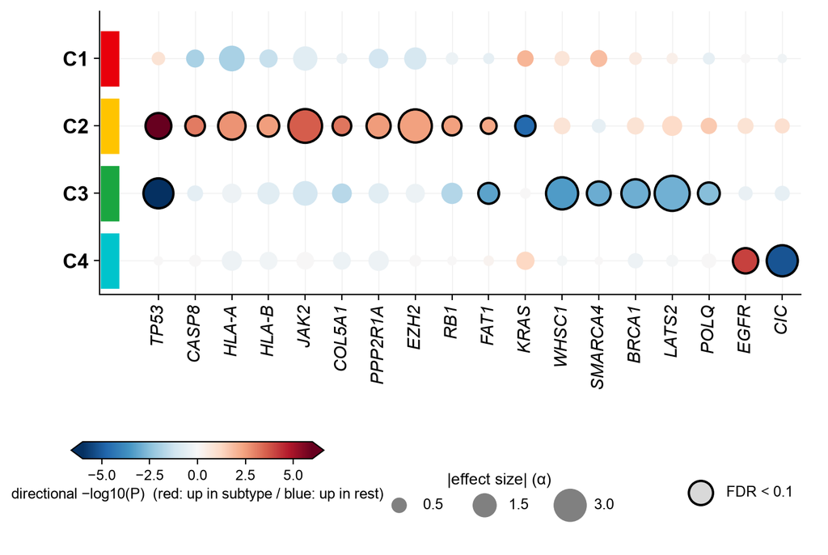

```r
cat(sprintf('<img src="%s" style="max-width:100%%; height:auto;" alt="Fig. 5a">',
            knitr::image_uri("analysis/assets/Figure5a_immune_landscape.png")))
```

## Significant gene × subtype associations

```r
datatable(
  sig[, .(gene, subtype = phenotype, dd.p = signif(dd.p, 3),
          dd.fdr = signif(dd.fdr, 3), direction, mut_freq)][order(subtype, dd.fdr)],
  options = list(pageLength = 20)
)
```

|  | gene | subtype | dd.p | dd.fdr | direction | mut_freq |
| --- | --- | --- | --- | --- | --- | --- |
| 1 | TP53 | C2 | 1.13e-16 | 2.49e-14 | up_in_subtype | 0.406 |
| 2 | KRAS | C2 | 2.11e-05 | 0.00232 | up_in_rest | 0.1284 |
| 3 | JAK2 | C2 | 0.000243 | 0.0178 | up_in_subtype | 0.0143 |
| 4 | COL5A1 | C2 | 0.00062 | 0.032 | up_in_subtype | 0.031 |
| 5 | CASP8 | C2 | 0.000728 | 0.032 | up_in_subtype | 0.0328 |
| 6 | HLA-A | C2 | 0.00197 | 0.0723 | up_in_subtype | 0.0239 |
| 7 | PPP2R1A | C2 | 0.00264 | 0.0789 | up_in_subtype | 0.0602 |
| 8 | HLA-B | C2 | 0.00323 | 0.0789 | up_in_subtype | 0.0203 |
| 9 | EZH2 | C2 | 0.00357 | 0.0789 | up_in_subtype | 0.013 |
| 10 | RB1 | C2 | 0.00359 | 0.0789 | up_in_subtype | 0.0444 |

[output cut: 10 more lines]